#This is an [R Markdown](http://rmarkdown.rstudio.com) Notebook. When you execute code within the notebook, the results appear beneath the code.

#Try executing this chunk by clicking the *Run* button within the chunk or by placing your cursor inside it and pressing *Cmd+Shift+Enter*.

```r
adult_df <- read.csv("adult.csv")
summary(adult_df)
```

```
      age         workclass             fnlwgt         education         education.num   marital.status      occupation        relationship
 Min.   :17.00   Length:32561       Min.   :  12285   Length:32561       Min.   : 1.00   Length:32561       Length:32561       Length:32561
 1st Qu.:28.00   Class :character   1st Qu.: 117827   Class :character   1st Qu.: 9.00   Class :character   Class :character   Class :character
 Median :37.00   Mode  :character   Median : 178356   Mode  :character   Median :10.00   Mode  :character   Mode  :character   Mode  :character
 Mean   :38.58                      Mean   : 189778                      Mean   :10.08
 3rd Qu.:48.00                      3rd Qu.: 237051                      3rd Qu.:12.00
 Max.   :90.00                      Max.   :1484705                      Max.   :16.00
     race               sex             capital.gain    capital.loss    hours.per.week  native.country     income.bracket
 Length:32561       Length:32561       Min.   :    0   Min.   :   0.0   Min.   : 1.00   Length:32561       Length:32561
 Class :character   Class :character   1st Qu.:    0   1st Qu.:   0.0   1st Qu.:40.00   Class :character   Class :character
 Mode  :character   Mode  :character   Median :    0   Median :   0.0   Median :40.00   Mode  :character   Mode  :character
                                       Mean   : 1078   Mean   :  87.3   Mean   :40.44
                                       3rd Qu.:    0   3rd Qu.:   0.0   3rd Qu.:45.00
                                       Max.   :99999   Max.   :4356.0   Max.   :99.00
```

** I’m comparing ‘age’ and ‘education.num’ because age and education often show interesting patterns.** ** Older people might have different education levels compared to younger ones. This can tell us how education trends have changed over time. It’s a quick way to spot if there’s a shift in education levels across different age groups.**

# Compare ‘age’ and ‘education.num’

```r
summary(adult$age)
```

```
   Min. 1st Qu.  Median    Mean 3rd Qu.    Max.
  17.00   28.00   37.00   38.58   48.00   90.00
```

```r
summary(adult$education.num)
```

```
   Min. 1st Qu.  Median    Mean 3rd Qu.    Max.
   1.00    9.00   10.00   10.08   12.00   16.00
```

Problem 1a. First, we look at the summary statistics for all the variables. Based on those metrics, including the quartiles, compare two variables. What can you tell about their shape from these summaries?

Ans. The age distribution is right-skewed, meaning most people are younger, but a few older individuals pull the mean higher. The education.num distribution is more symmetrical, with most people having (around 9-12 years) of education, and there are no extreme outliers affecting the mean.

Problem 1b. Use a visualization to get a fine-grain comparison (you don’t have to use QQ plots, though) of the distributions of those two variables. Why did you choose the type of visualization that you chose? How do your part (a) assumptions compare to what you can see visually?

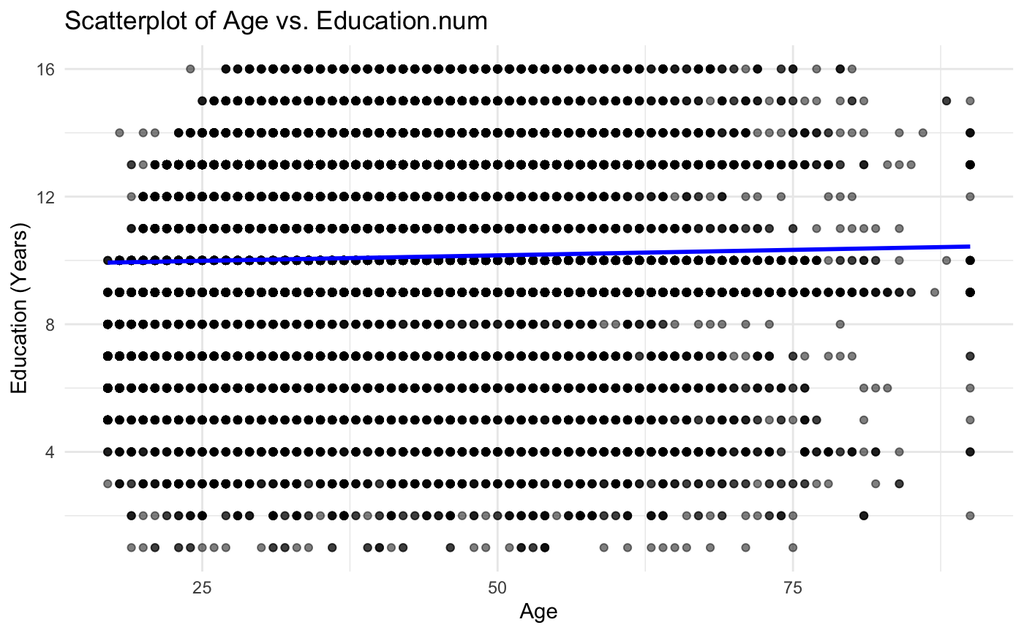

```r
library(ggplot2)
ggplot(adult_df, aes(x = age, y = education.num)) +
  geom_point(alpha = 0.5) + # Scatterplot points
  geom_smooth(method = "lm", col = "blue", se = FALSE) + # Add a linear regression line
  labs(title = "Scatterplot of Age vs. Education.num",
       x = "Age", y = "Education (Years)") +
  theme_minimal()
```

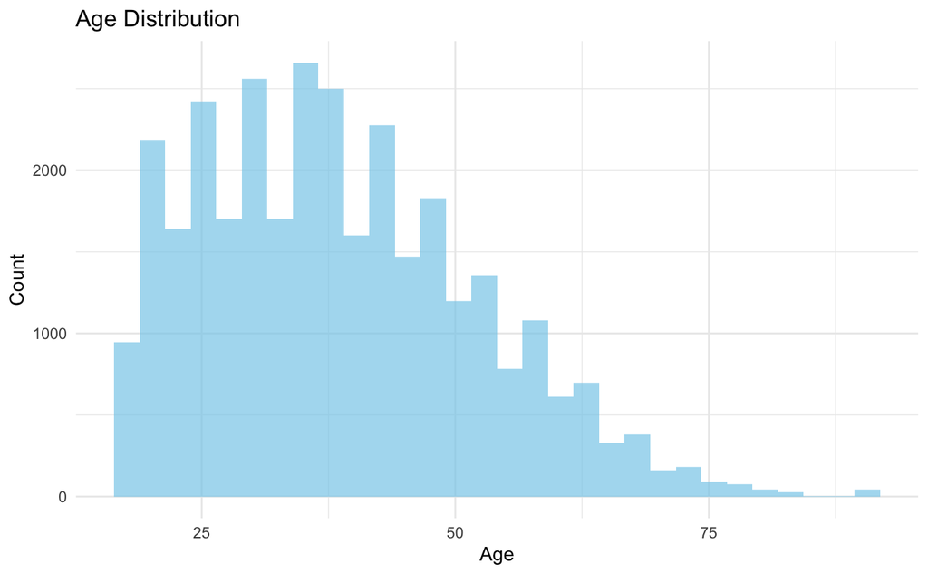

```r
# Histograms for 'age' and 'education.num'
# Age Distribution
ggplot(adult_df, aes(x = age)) +
  geom_histogram(bins = 30, fill = "skyblue", alpha = 0.7) +
  labs(title = "Age Distribution", x = "Age", y = "Count") +
  theme_minimal()
```

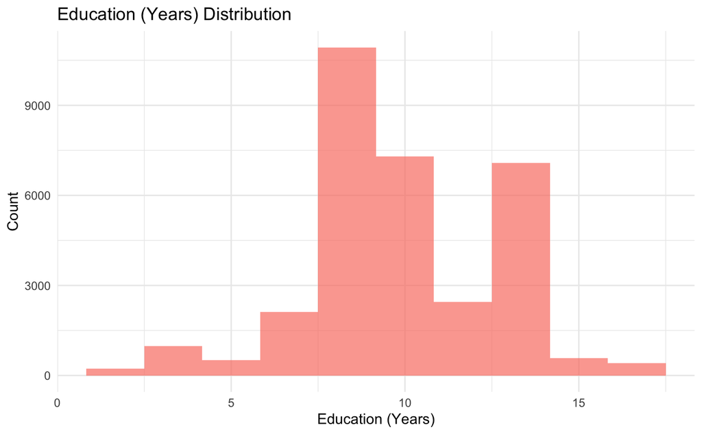

```r
# Education.num Distribution
ggplot(adult_df, aes(x = education.num)) +
  geom_histogram(bins = 10, fill = "salmon", alpha = 0.7) +
  labs(title = "Education (Years) Distribution", x = "Education (Years)", y = "Count") +
  theme_minimal()
```

- Explanation for choosing the Visualization:
- I chose the scatterplot to easily see how education varies with age. The trend line gives an overall sense of whether the relationship is positive or negative.
- I added histograms to compare the distribution of each variable individually. This helps visualize skewness, spread, and the concentration of data points for each variable.
- Comparison to Part (a) Assumptions:
- The scatterplot confirms that there is no strong linear relationship between age and education, but we can see some grouping (younger individuals tend to have lower or middle levels of education).
- The histograms visually confirm the assumption from Part (a). The age distribution is right-skewed, and the education.num distribution is more symmetrical, with most individuals having between 9 and 12 years of education.

Problem 1c. Now create a scatterplot matrix of the numerical variables. What does this view show you that would be difficult to see looking at distributions?

[output not shown]

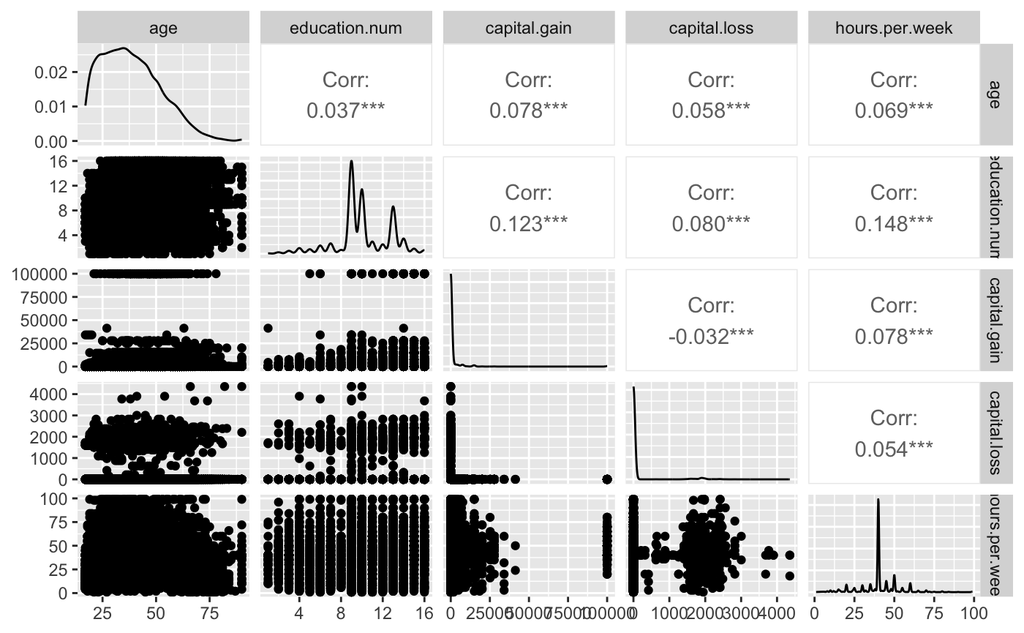

```r
library(GGally)

numeric_columns <- adult_df[, c("age", "education.num", "capital.gain", "capital.loss", "hours.per.week")]

# Create a scatter-plot matrix
ggpairs(numeric_columns)
```

#### What This View Shows?

- A scatterplot matrix shows pairwise relationships between each pair of numerical variables.
- We can visually detect correlations between variables. For example:
  - If two variables tend to form a straight line, they are likely correlated.
  - If the scatter is spread out randomly, there is little to no correlation.
- We can also spot outliers and general trends between pairs of variables.

#### What Is Hard to See in Distributions:

- Distributions only show how data is spread for one variable at a time.
- Scatterplot matrices, on the other hand, let you see how two variables relate to each other at the same time (e.g., how age and education are related), which is not visible when just looking at histograms or single-variable distributions.

Problem 1d. These data are a selection of US adults. It might not be a very balanced sample, though. Take a look at some categorical variables and see if any have a lot more of one category than others. There are many ways to do this, including histograms and following tidyererse group_by with count. I recommend you try a few for practice.

```r
library(dplyr)
```

```r
adult_df %>%
  group_by(workclass) %>%
  summarise(count = n()) %>%
  arrange(desc(count))


adult_df %>%
  group_by(race) %>%
  summarise(count = n()) %>%
  arrange(desc(count))


adult_df %>%
  group_by(education) %>%
  summarise(count = n()) %>%
  arrange(desc(count))
```

[output not shown]

```r
# Visualizing the distribution of 'workclass'
ggplot(adult_df, aes(x = workclass)) +
  geom_bar(fill = "skyblue") +
  labs(title = "Distribution of Workclass", x = "Workclass", y = "Count") +
  theme_minimal()

# Visualizing the distribution of 'race'
ggplot(adult_df, aes(x = race)) +
  geom_bar(fill = "salmon") +
  labs(title = "Distribution of Race", x = "Race", y = "Count") +
  theme_minimal()

# Visualizing the distribution of 'education'
ggplot(adult_df, aes(x = education)) +
  geom_bar(fill = "lightgreen") +
  labs(title = "Distribution of Education", x = "Education", y = "Count") +
  theme_minimal()
```

[output not shown]

Ans.I analyzed the categorical variables such as workclass, race, and education to check if the dataset is balanced.

- For workclass, the distribution is heavily skewed toward the “Private” sector, meaning most individuals in the dataset belong to this category. Other workclasses like “Self-emp” and “Government” are present but in much smaller numbers, indicating an imbalance.
- For race, there is also an imbalance. The “White” race has the highest count, making up the majority of the dataset, while other racial groups like “Black” and “Asian” have much smaller representations.
- For education, the distribution shows that most people are “HS-grad” or “Some-college.” Higher education levels like “Doctorate” and “Prof-school” are much less common, indicating fewer highly educated individuals in the sample.

Problem 1e. Now we’ll consider a relationship between two categorical variables. Create a cross tabulation and then a corresponding visualization and explain a relationship between some of the values of the categoricals.

```r
cross_tab <- table(adult_df$education, adult_df$income.bracket)
print(cross_tab)
```

[output not shown]

```r
unique(adult_df$income.bracket)
```

[output not shown]

```r
ggplot(adult_df, aes(x = education, fill = income.bracket)) +
  geom_bar(position = "fill") +
  labs(title = "Education vs Income Bracket", x = "Education Level", y = "Proportion") +
  theme(axis.text.x = element_text(angle = 45, hjust = 1)) +
  scale_fill_manual(values = c(" <=50K" = "skyblue", " >50K" = "salmon"))
```

[output not shown]

- People with lower levels of education (like “HS-grad” or “Some-college”) tend to fall more frequently into the <=50K income bracket.
- On the other hand, individuals with higher education (like “Bachelors”, “Doctorate” or “Masters”) are more likely to fall into the >50K income bracket.

Problem 2. In this question, you will integrate data on different years into one table and use some reshaping to get a visualization. There are two data files: population_even.csv and population_odd.csv. These are population data for even and odd years respectively.

```r
# first load the data sets
population_even <- read.csv("population_even.csv")
head(population_even)
```

[output not shown]

```r
population_odd <- read.csv("population_odd.csv")
head(population_odd)
```

[output not shown]

1. Join the two tables together so that you have one table with each state’s population for years 2010-2019. If you are unsure about what variable to use as the key for the join, consider what variable the two original tables have in common. (Show a head of the resulting table.) Ans. We are starting by loading two CSV files that have population data for even and odd years, and then combining them into one table using the “STATE” column. This lets us have population data for every year from 2010 to 2019 for each state.

```r
# merge the data sets
combined_population <- full_join(population_even, population_odd, by = "STATE")
head(combined_population)
```

[output not shown]

2. Clean this data up a bit (show a head of the data after):
- Remove the duplicate state ID column if your process created one.
- Rename columns to be just the year number.
- Reorder the columns to be in year order.

Ans. Remove duplicate columns: Since the tables had a common column for the state names, we only need one of them. Rename columns: We simplify the column names by just using the year (like “2010”, “2011”, etc.). Reorder the columns: This ensures that the data is in the correct order from 2010 to 2019.

```r
# Check the column names to verify the structure
colnames(combined_population)
```

[output not shown]

```r
# Remove the duplicate column
combined_population <- combined_population %>% select(-NAME.y)

colnames(combined_population) <- c("STATE", "NAME", "2010", "2012", "2014", "2016", "2018",
                                   "2011", "2013", "2015", "2017", "2019")

combined_population <- combined_population %>%
  select(STATE, NAME, `2010`, `2011`, `2012`, `2013`, `2014`, `2015`, `2016`, `2017`, `2018`, `2019`)


head(combined_population)
```

[output not shown]

```r
library(zoo)
```

```r
combined_population <- combined_population %>%
  mutate(across(where(is.numeric), ~ ifelse(is.na(.), zoo::na.approx(.), .)))
head(combined_population)
```

[output not shown]

4. We can use some tidyverse aggregation to learn about the population.
5. Get the maximum population for a single year for each state. Note that because you are using an aggregation function (max) across a row, you will need the rowwise() command in your tidyverse pipe. If you do not, the max value will not be individual to the row. Of course there are alternative ways. Ans. We want to calculate the maximum population for each state across the years 2010–2019. For this, we’ll use the rowwise() function from the tidyverse so that the max() function operates on a row-by-row basis.

```r
combined_population <- combined_population %>%
  rowwise() %>%
  mutate(max_population = max(c_across(`2010`:`2019`), na.rm = TRUE))

head(combined_population %>% select(STATE, NAME, max_population))
```

[output not shown]

2. Now get the total population across all years for each state. This should be possible with a very minor change to the code from (d). Why is that? Ans. To calculate the total population across all years (2010–2019) for each state, we just need to replace the max() function with sum() in the same code. This is a minor change because the structure of the task is similar (operating row-wise over a range of columns).

```r
combined_population <- combined_population %>%
  rowwise() %>%
  mutate(total_population = sum(c_across(`2010`:`2019`), na.rm = TRUE))

head(combined_population %>% select(STATE, NAME, total_population))
```

[output not shown]

5. Finally, get the total US population for one single year. Keep in mind that this can be done with a single line of code even without the tidyverse, so keep it simple. Ans. To get the total US population for a single year (e.g., 2019), we can simply sum the population for that year across all states.

```r
total_population_2019 <- sum(combined_population$`2019`, na.rm = TRUE)

total_population_2019
```

[output not shown]

Problem 3 (15 points) Continuing with the data from Problem 2, let’s create a graph of population over time for a few states (choose at least three yourself). This will require another data transformation, a reshaping. In order to create a line graph, we will need a variable that represents the year, so that it can be mapped to the x axis. Use a transformation to turn all those year columns into one column that holds the year, reducing the 10 year columns down to 2 columns (year and population). Once the data are in the right shape, it will be no harder than any line graph: put the population on the y axis and color by the state. One important point: make sure you have named the columns to have only the year number (i.e., without popestimate). That can be done manually or by reading up on string (text) parsing (see the stringr library for asuper useful tool). Even after doing that, you have a string version of the year. R is seeing the ‘word’ spelled two-zero-one-five instead of the number two thousand fifteen. It needs to be a number to work on a time axis. There are many ways to fix this. You can look into type_convert or do more string parsing (e.g., stringr). The simplest way is to apply the transformation right as you do the graphing. You can replace the year variable in the ggplot command with as.integer(year).

- Step 1: Reshape the Data

```r
library(dplyr)
library(tidyr)
library(ggplot2)

long_population <- combined_population %>%
  pivot_longer(cols = "2010":"2019", names_to = "year", values_to = "population")

# Convert 'year' column to numeric type to be used in plotting
long_population$year <- as.integer(long_population$year)

head(long_population)
```

[output not shown]

- Step 2: Filter for a few states
- Choosing three states that we want to plot. For example, let’s use Alabama, California, and New York.

```r
states_to_plot <- long_population %>%
  filter(NAME %in% c("Alabama", "California", "New York"))

head(states_to_plot)
```

[output not shown]

- Step 3: Create the line graph

```r
ggplot(states_to_plot, aes(x = year, y = population, color = NAME)) +
  geom_line(linewidth = 1) +  # Replacing size with linewidth
  labs(title = "Population Over Time for Selected States",
       x = "Year",
       y = "Population") +
  theme_minimal()
```

[output not shown]

#### Problem 4 - Short Answer Questions

1. Two Ways Data Can Be Dirty and Solutions
1. Missing Data: Some entries may have missing values, like a customer’s age or purchase amount. Solution: Use imputation to fill in missing values (e.g., average for numerical data or the most common category for categorical data).
2. Inconsistent Data: Data might have inconsistencies, like different spellings for the same product (“milk” vs “Milk”). Solution: Standardize the data by converting everything to a uniform format, such as lowercase for text or consistent units for numerical data.
2. Data Mining Functionalities for These Questions
1. Grouping Customers by Similar Purchases: Functionality: Clustering. Clustering algorithms like k-means can group customers who buy similar items into five different segments.
2. Predicting if a Customer Will Buy Milk: Functionality: Classification. A classification model like logistic regression or decision trees can predict if a customer will buy milk based on their purchase history.
3. Finding Sets of Products Bought Together: Functionality: Association Rule Mining. Techniques like Apriori or FP-Growth can identify sets of products frequently purchased together (e.g., market basket analysis).
3. Is This a Data Mining Task?
1. Organizing Customers by Education Level: Not data mining. This is just a data organization task, not a discovery of patterns or insights.
2. Computing Total Sales of a Company: Not data mining. This is basic calculation or aggregation, not an analytical task involving pattern discovery.
3. Sorting Students by ID Number: Not data mining. Sorting is a simple data manipulation task, not an exploration or modeling activity.
4. Predicting Outcomes of Dice Tosses: Not data mining. Dice tosses are random and can’t be predicted based on past patterns.
5. Predicting Future Stock Prices: Data mining. This involves using historical data to forecast future trends, which is a typical use of data mining models.